# Machine Learning in Finance

Module 3

Author

Affiliation

Matthew G. Son

University of South Florida

# Review

## Unsupervised Learning

Unsupervised learning: clustering, association, dimensionality reduction

In Finance : Clustering & Dimensionality reductions

- K-means clustering
- Hierarchical clustering
- Principal Component Analysis (PCA)

## Clustering in Finance

**Banking**

Suppose you are a bank and have hundreds of thousands of customers and more than 100 features describing each

- Unsupervised learning algorithms can be used to divide your customers into **clusters**
- To anticipate their needs
- Communicate more effectively

## Dimensionality Reduction in Finance

**Banking**

Suppose you are a bank and have hundreds of thousands of customers and more than 100 features describing each

- Or, you can reduce the features needed from 100 to 15 features
- Removes redundancy and efficiency for further analysis

# Machine Learning concepts

## Feature scaling

*Feature scaling* is a technique to standardize the range of independent variables (X, or features).

Common methods are:

1. Z-score scaling (standardization)
2. Min-max scaling

## Why feature scaling?

Not all algorithms **require** feature scaling. Some algorithms are especially susceptible to scale effect.

**Issues** caused by improper scaling:

1. Poor performance
2. Longer training times
3. Misleading feature importance

## Feature scaling

1. Z-score scaling:

$$Value \rightarrow \frac{Value - Mean}{SD}$$

2. Min-Max scaling:

$$Value \rightarrow \frac{Value - Minimum}{Maximum - Minimum}$$

## Exercise

You are given the following vector of daily returns (in decimal form) for a stock:

```r
daily_returns <- c(0.02, -0.01, 0.03, -0.02)
```

Q1. Scale using Z-score scaling.

$$Value \rightarrow \frac{Value - Mean}{SD}$$

Q2. Scale using Min-Max scaling.

$$Value \rightarrow \frac{Value - Minimum}{Maximum - Minimum}$$

## Euclidean Distance

Calculate straight line **distance** between two points

- In two dimension space,
  $$d(A,B) = \sqrt{(x_B -x_A)^2 + (y_B - y_A)^2}$$

## Pen and Paper Exercise

**Euclidean Distance**

Consider two points in a two-dimensional space:

A(2, 3) and B(7, 11)

Calculate the Euclidean distance d(A,B) between these two points using the formula:

$$d(A,B) = \sqrt{(x_B - x_A)^2 + (y_B - y_A)^2}$$

## Verify

```r
A <- c(2, 3)
B <- c(7, 11)
d <- function(a, b) {
  return(sqrt(sum((b - a)^2)))
}
d(A, B)
```

```
[1] 9.433981
```

## Centroid

The centroid of a cluster is the average of all points in that cluster

- In 2D, it is the mean of all $x$ and $y$ coordinates:
  $$\textrm{Centroid} = \left( \frac{1}{n} \sum_{i=1}^n x_i,\ \frac{1}{n} \sum_{i=1}^n y_i \right)$$
- Acts as the center or representative point of the cluster

## Pen and Paper Exercise

**Centriod**

Consider two points in a two-dimensional space:

A(2, 3) and B(7, 11)

Calculate the centroid.

## Within cluster Sum of Squares (WSS)

Within cluster Sum of Squared (WSS) for cluster $j$ is:

$$WSS_j = \sum\limits_{i=1}^nd_i^2$$

- $d_i^2$ is squared distance of $i$ to centroid
- Measure how “sparse” the cluster is
- Higher the sparser

## Pen and Paper Exercise

**Within Cluster Sum of Squares (WSS)**

A cluster has three data points:

P_1(1, 2), P_2(2, 4), and P_3(3, 6).

The centroid of this cluster is given as C(2, 4).

Calculate the WSS for this cluster, defined as:
$$WSS = \sum_{i=1}^{n} d(P_i, C)^2$$

## Verify

```r
P1 <- c(1, 2)
P2 <- c(2, 4)
P3 <- c(3, 6)

C <- c(2, 4)

wss <- sum(d(P1, C)^2, d(P2, C)^2, d(P3, C)^2)
```

## Total WSS / Inertia

**Inertia** is the **Total** “within cluster sum of squares (WSS)” of distance to centroid:

$$\mathrm{Inertia} = \sum\limits_{j=1}^K\mathrm{WSS}_j$$

- To evaluate **quality of clusters** formed by K-means
- **Similar to error metric** for K-means (we try to minimize it)

## Pen and Paper Exercise

**Inertia**

Suppose you have three clusters with the following within-cluster sums of squares (WSS):

- Cluster 1: WSS_1 = 100
- Cluster 2: WSS_2 = 150
- Cluster 3: WSS_3 = 200

How do you calculate the inertia for three clusters?

# K-means

## K-means

A popular clustring algorithm in Finance.

A **Partitioning** method that clusters dataset into `k` distinct subsets

Algorithm:

- Find `k` cluster centroids that minimize distances within cluster data points
- Initiate random starting centroids and find the optimal points

## Visual Summary

```
`nframes` and `fps` adjusted to match transition
```

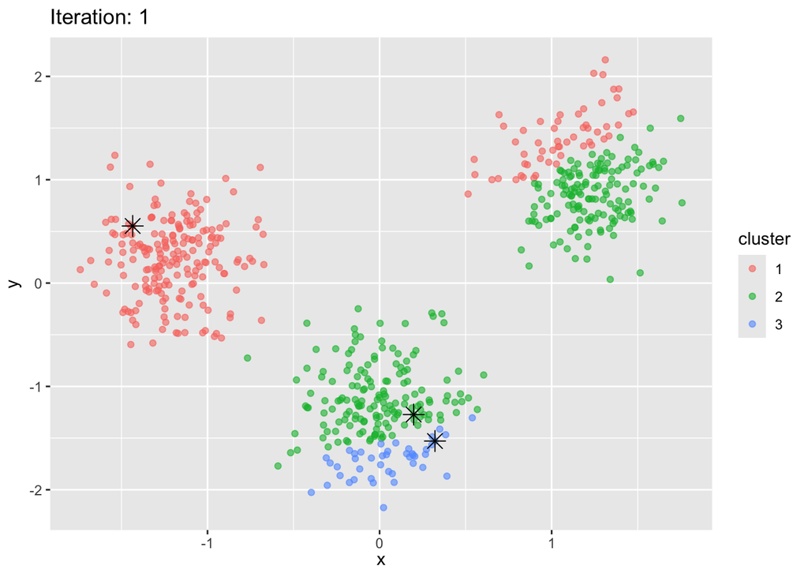

## Algorithm Summary

1. Initialization:
- Choose the number of clusters, K.
- Randomly select K data points (without replacement) to serve as the initial centroids.
2. Assignment:
- Assign each data point to the nearest centroid. The result is K clusters of data points.
3. Update:
- For each of the K clusters, compute the new centroid (mean) of all the data points assigned to that cluster.
4. Convergence Check:
- If the centroids do not change (or change very little) then stop. Otherwise, return to the “Assignment” step.

## Algorithm Summary (Detailed)

Input:

- $X = \{x_1, x_2, …, x_n\}$: a set of data points (each observation, $n$ toal observations)
- $K$ : number of clusters

Output:

- A set of clusters $C = \{C_1, C_2, …, C_K\}$

Algorithm:

1. Initialize
   - Randomly select $K$ points from $X$ as centroids: $\mu_1, \mu_2, …, \mu_K$
2. Repeat until convergence
   - For each $x_i \in X$: find the nearest centroid $\mu_j = argmin_{j\in{1,…,K}} \ d(x_i, \mu_j)$
   - Assign $C_j \leftarrow x_i$
   - For each cluster $C_j$ : update centroid, $\mu_j = \frac{1}{|C_j|}\sum\limits_{x_i\in C_j} x_i$
3. Termination
   - Terminate if $\Delta\mu_j = \sqrt{\sum(\mu_{j,i}^t - \mu_{j,i}^{t-1})^2} < \epsilon$

## How many `K`s?

Choosing the appropriate number of clusters (`K`) is crucial:

- It significantly influences the outcomes of your clustering

Then, how can we choose `K`?

## How to choose `K`s?

1. Heuristics: if strong prior exists (i.e. theory, regulations)
2. With statistical methods:
- Elbow method
- Silhouette Method
- Gap statistic

## Elbow method

Calculate **Inertia** (i.e. total within-cluster sum of squares, WSS):

- For each values of `K` from small to large
- Pick a point when reduction in Inertia **slows down**

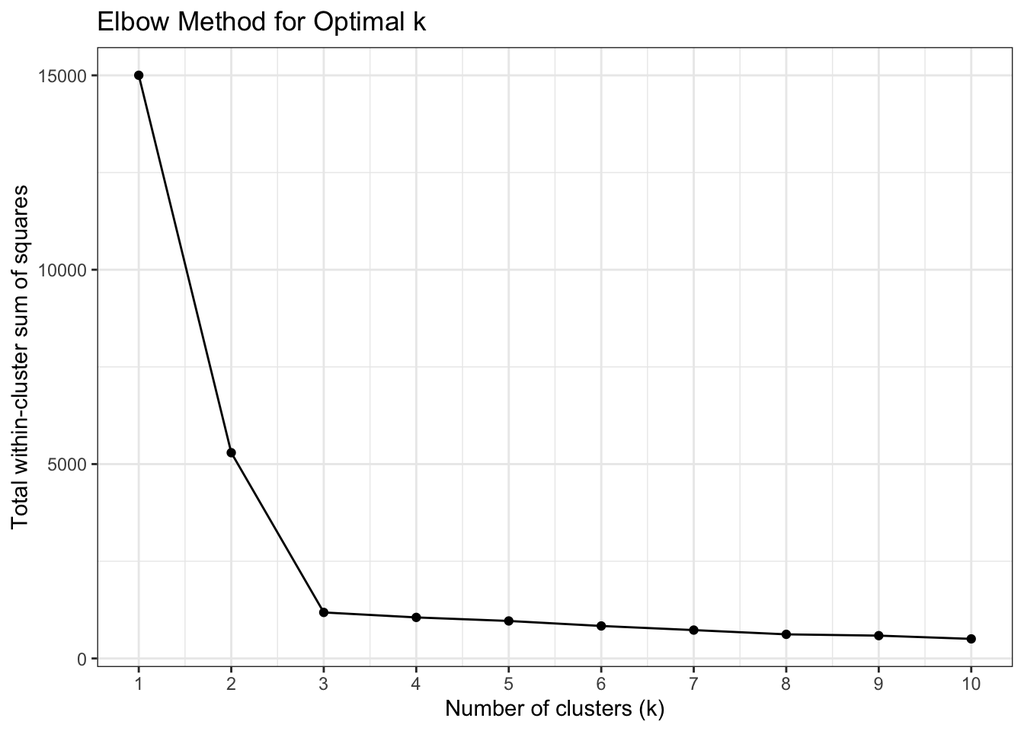

## Silhouette Method

Silhouette score measures how close each point $i$ in one cluster is to the points in neighboring clusters.

$$S_i = \frac{b_i - a_i}{\max{[a_i, b_i]}}$$

```
-   $a_i$: $i$'s average distance within cluster points
-   $b_i$: $i$'s average distance with neighbor points (K-1), then pick minimum
```

- Calculate $S_i$ for all points and get average for each K
- Pick K with highest score

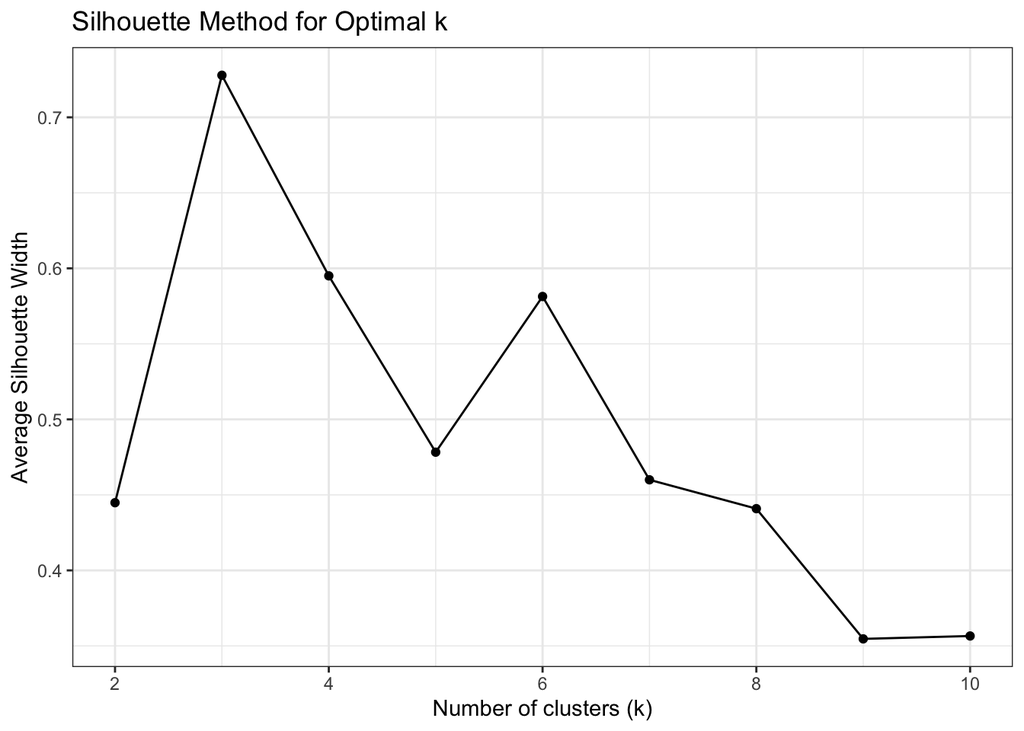

## Gap statistic

Compares inertia for different values of `K` with random clustering.

Idea: the compactness of clustering should be better than that of random clustering

$$Gap(k) = m_k - w_k$$

- $m_k$: log mean of inertia from randomly created data (bootstrapping, B times)
- $w_k$: inertia based on K-means

Choose $k$ where

$$Gap(k) >= Gap(k+1) - s_{k+1}$$

- $s_k$: standard deviation of log of inertia of bootstrapping

# Caveats of K-means

## Curse of Dimensionality

The concept of “distance” becomes less meaningful in large dimension

- the variation in distance become less as **dimension increases**
- making all points appear almost equidistant

## Distance distribution

1000 Randomized samples with varing dimensions 1 to 500

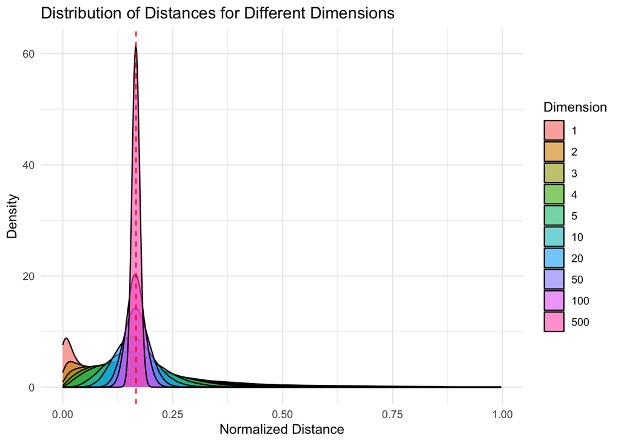

## Prone to Seed

K-means are sensitive to initialization (seed selection)

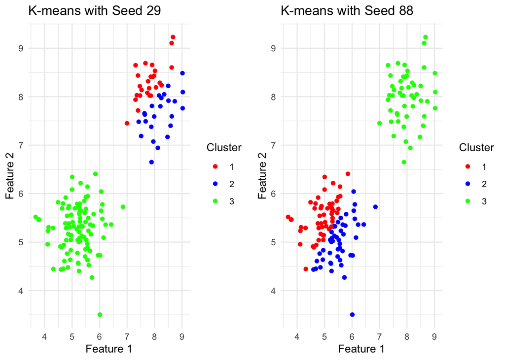

## How to solve seed problem?

- Select good seeds using a heuristic (theory)
- Fix a random seed for reproducibility
- Try out multiple starting points: (cross) validation

## Validation on K-means

Though K-means is unsupervised, Inertia can be used as if an error metric as in supervised learning. (`h2o` provides this feature.)

- Train K-means model and use the model to cluster on validation set
- Check variabiliy of inertia with (cross) validation
- If inertia is stable: not prone to seed

# H2O

## H2O ML

Open-source, in-memory platform for distributed, scalable machine learning

- Integrates with big data infrastructure (e.g., Hadoop and Spark)
- Provides a broad ML algorithms
- AutoML : Automatic model training
- High-Performance: Written in Java, robust and fast for large datasets
- Multi-Language Support: Accessible via R, Python, Java, and Scala
- Web API & GUI: Offers an interactive web interface for model monitoring and management

## Note

H2O’s R API syntax mostly follows the base R.

Most of dplyr verbs doesn’t directly work on `H2O Frame`.

## Prep

1. **java** needes to be installed (**java** or **openjdk** 11 recommended, or after)
- You can find from **installation guide** on Canvas.
2. Install package:

```r
install.packages("h2o")
install.packages("cluster") # for silhouette
install.packages("GGally")
```

# K-means Lab Walkthrough

## K-means with H2O

In the lab walkthrough, we will use `h2o` to perform K-Means clustering. The workflow includes:

1. Initializing H2O
2. Importing or converting data into H2O frames
3. Training ML models using `h2o` algorithms
4. Evaluating and interpreting results
5. Exporting predictions or models

## Import data

```r
library(tidyverse)
library(cluster) # needed for silhouette

country_risk <- read_csv("ml_data/Country Risk 2019 Data.csv")
# Colume GDP Growth has whitespace
country_risk |>
  head(4)
```

```
# A tibble: 4 × 6
  Country   Abbrev Corruption Peace Legal `GDP Growth`
  <chr>     <chr>       <dbl> <dbl> <dbl>        <dbl>
1 Albania   AL             35  1.82  4.55         2.98
2 Algeria   DZ             35  2.22  4.43         2.55
3 Argentina AR             45  1.99  5.09        -3.06
4 Armenia   AM             42  2.29  4.81         6
```

## Clean data

```r
country_risk <- country_risk |>
  janitor::clean_names() # clean names

country_risk |>
  head(4)
```

```
# A tibble: 4 × 6
  country   abbrev corruption peace legal gdp_growth
  <chr>     <chr>       <dbl> <dbl> <dbl>      <dbl>
1 Albania   AL             35  1.82  4.55       2.98
2 Algeria   DZ             35  2.22  4.43       2.55
3 Argentina AR             45  1.99  5.09      -3.06
4 Armenia   AM             42  2.29  4.81       6
```

## Variable Definitions

1. Real GDP growth (from IMF)
   - Higher the better
2. Corruption Index (Transparency International)
   - Higher the better (no corruption)
3. Peace Index (Institute for Economics and Peace)
   - Lower the better (very peaceful)
4. Legal risk index (Property Rights Association)
   - Higher the better (favorable)

## Country Risk data

Evaluating country-level risk is important in international finance:

- For portfolio diversification
- Currency evaluation
- Bond risk evaluation

Challenge is, there are so many nations!

- Let’s **cluster** them into groups with similar characteristics

## Variable Correlations

Pairwise plots to explore variable relationships:

- Corruption and Legal have strong correlations
- GDP Growth is distinct from others

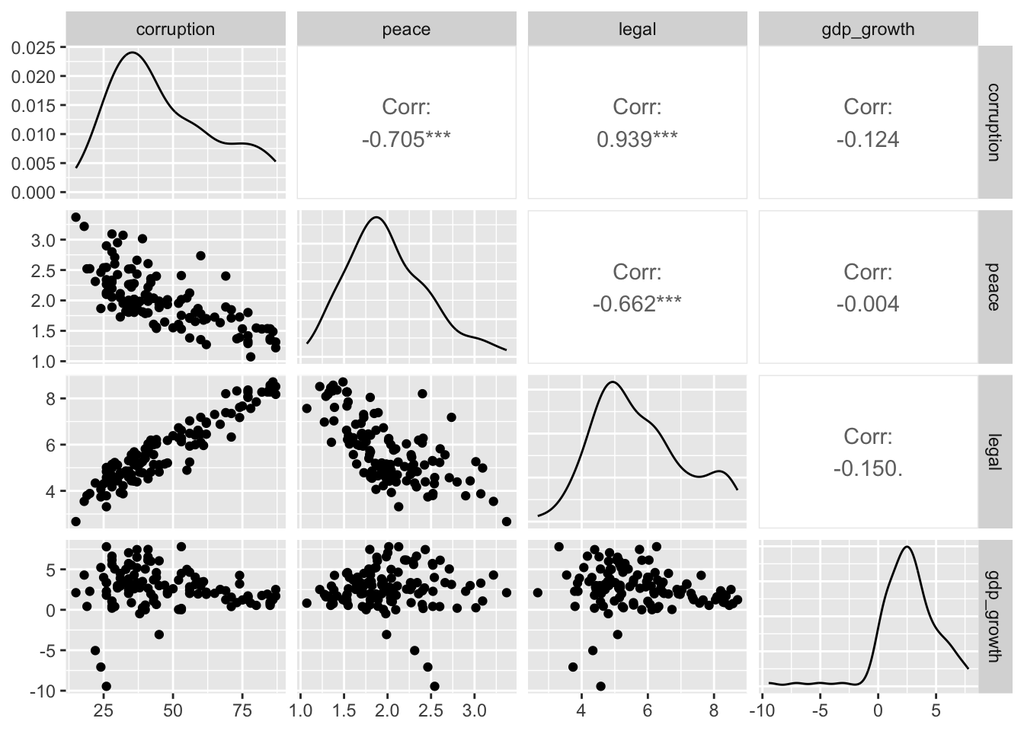

```r
library(GGally)
ggpairs(
  country_risk |>
    select(-country, -abbrev)
)
```

## How many nations?

```r
country_risk |>
  select(country) |>
  n_distinct()
```

```
[1] 121
```

## Initiate h2o

Initiate a `h2o` java server locally with `h2o.init()`.

**Tip**

If there is an external server running, you can connect to the server instead with `h2o.init()`. Check the documentations.

```r
library(h2o)
h2o.init() # initiate h2o server locally
```

## Upload to H2O

Since the H2O server is running separately, you need to upload the data to the server.

If you have a data.frame in R, send the data to H2O with `as.h2o()`

```r
country_risk_h2o <- as.h2o(
  country_risk
)
```

## A dry run with K = 3

Let’s dry run a kmeans algorithm with **K = 3**. We’ll expand our analysis with elbow method to determine optimal K.

```r
initial_kmeans_model <-
  h2o.kmeans(
    training_frame = country_risk_h2o,
    x = c("corruption", "peace", "legal", "gdp_growth"),
    k = 3,
    standardize = TRUE,
    seed = 123 # random initial point seed
  )
h2o.tot_withinss(initial_kmeans_model) # get inertia
```

## Clustering result

Suppose we wanted to use K=3 to cluster our data. We make model predictions with the *k-means* model.

```r
country_risk_h2o[["cluster"]] <- h2o.predict(
  initial_kmeans_model, # Model
  country_risk_h2o # Data to make prediction
)
print(country_risk_h2o)
```

## Elbow method

The elbow method helps us choose a good value for **K** (the number of clusters) by:

1. Trying several values of K (e.g., K = 1 to 20).
2. Measuring how well the clusters fit the data (using the Total Within-Cluster Sum of Squares, or WSS).
3. Plotting WSS vs K.
4. Looking for an “elbow” — the point where adding more clusters stops giving big improvements.

## Define function

```r
get_inertia <- function(k, data = country_risk_h2o) {
  km_model <- h2o.kmeans(
    training_frame = data,
    x = c("corruption", "peace", "legal", "gdp_growth"),
    k = k, # specified from function
    standardize = TRUE,
    seed = 123
  )
  return(h2o.tot_withinss(km_model))
}
```

## Summary table with map

```r
# Loop over k values
k_values <- 1:20
elbow_results_h2o <- tibble(
  K = k_values,
  Inertia = map_dbl(k_values, get_inertia)
)
```

## Visualize Elbow

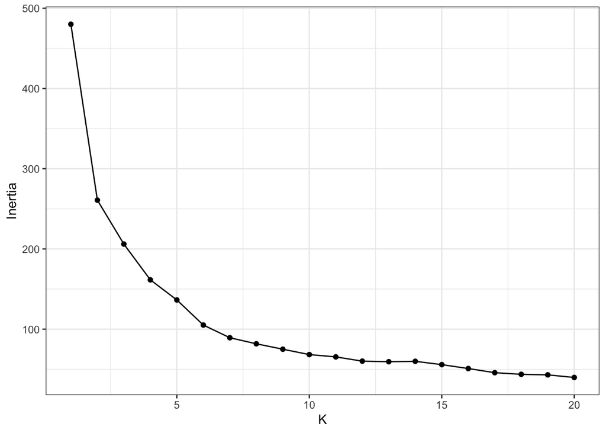

```r
elbow_results_h2o |>
  ggplot(aes(x = K, y = Inertia)) +
  geom_point() +
  geom_line() +
  theme_bw()
```

## Clustering result

Let’s use `K = 6` for our final model.

```r
k6_model <- h2o.kmeans(
  training_frame = country_risk_h2o,
  x = c("corruption", "peace", "legal", "gdp_growth"),
  k = 6,
  standardize = TRUE,
  seed = 123
)

# Get cluster assignments
groups <- as.vector(h2o.predict(k6_model, country_risk_h2o))
```

```r
# Assign cluster results on R dataframe
country_risk <- country_risk |>
  mutate(cluster = groups)
head(country_risk)
```

```
# A tibble: 6 × 7
  country   abbrev corruption peace legal gdp_growth cluster
  <chr>     <chr>       <dbl> <dbl> <dbl>      <dbl>   <int>
1 Albania   AL             35  1.82  4.55       2.98       0
2 Algeria   DZ             35  2.22  4.43       2.55       4
3 Argentina AR             45  1.99  5.09      -3.06       4
4 Armenia   AM             42  2.29  4.81       6          0
5 Australia AU             77  1.42  8.36       1.71       3
6 Austria   AT             77  1.29  8.09       1.60       3
```

## Analysis on Cluster Groups

Let’s skim the first 2 observations of each group.

```r
country_risk |>
  group_by(cluster) |>
  slice(1:2)
```

```
# A tibble: 12 × 7
# Groups:   cluster [6]
   country   abbrev corruption peace legal gdp_growth cluster
   <chr>     <chr>       <dbl> <dbl> <dbl>      <dbl>   <int>
 1 Albania   AL             35  1.82  4.55      2.98        0
 2 Armenia   AM             42  2.29  4.81      6           0
 3 Iran      IR             26  2.54  4.58     -9.46        1
 4 Nicaragua NI             22  2.31  4.34     -5.04        1
 5 Burundi   BI             19  2.52  3.80      0.419       2
 6 Cameroon  CM             25  2.54  4.31      4.00        2
 7 Australia AU             77  1.42  8.36      1.71        3
 8 Austria   AT             77  1.29  8.09      1.60        3
 9 Algeria   DZ             35  2.22  4.43      2.55        4
10 Argentina AR             45  1.99  5.09     -3.06        4
11 Botswana  BW             61  1.68  5.96      3.48        5
12 Chile     CL             67  1.63  6.88      2.52        5
```

Visualize summary statistics on each cluster group. How do you interpret the grouping results?

```r
country_risk |>
  group_by(cluster) |>
  summarize(across(!c(country, abbrev), mean))
```

```
# A tibble: 6 × 5
  cluster corruption peace legal gdp_growth
    <int>      <dbl> <dbl> <dbl>      <dbl>
1       0       37.7  2.01  5.00       5.32
2       1       24    2.44  4.22      -7.19
3       2       26.6  2.84  4.28       2.50
4       3       80.5  1.42  8.18       1.48
5       4       37.2  2.12  5.18       1.54
6       5       59.6  1.75  6.65       2.43
```

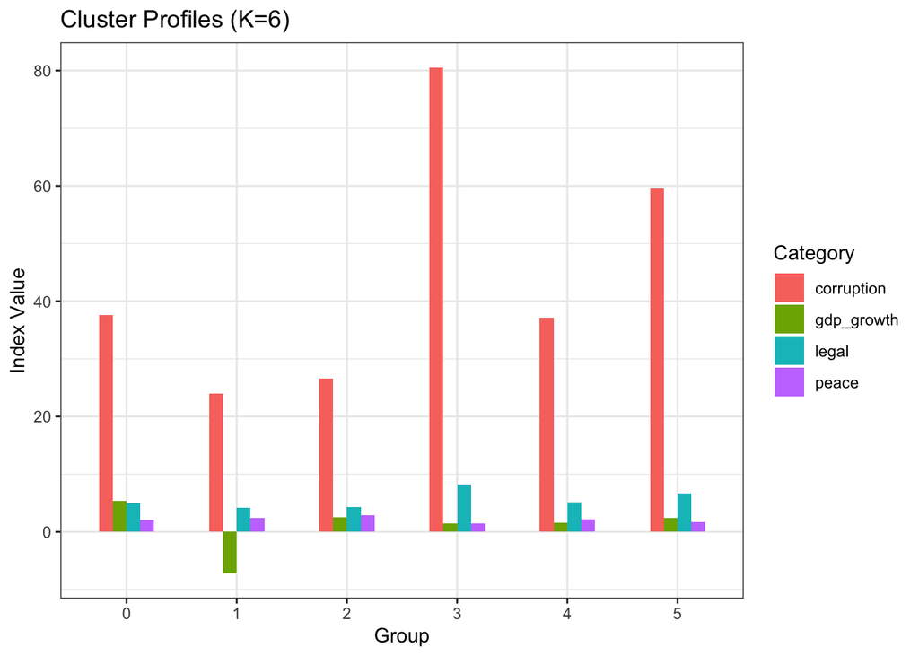

```r
country_risk |>
  group_by(cluster) |>
  summarize(across(!c(country, abbrev), mean)) |>
  pivot_longer(-cluster) |>
  ggplot(aes(x = as.factor(cluster), y = value, fill = name)) +
  geom_col(position = "dodge", width = 0.5) +
  labs(
    x = "Group",
    y = "Index Value",
    fill = "Category",
    title = "Cluster Profiles (K=6)"
  ) +
  theme_bw()
```

## Appendix: Silhouette Method

Silhouette score can be computed using `cluster::silhouette()`. It requires:

- Cluster assignments (we use **H2O**)
- Distance matrix

```r
library(cluster)

get_silhouette <- function(k) {
  # Fit k-means using H2O
  km_model <- h2o.kmeans(
    training_frame = country_risk_h2o,
    x = c("corruption", "peace", "legal", "gdp_growth"),
    k = k,
    standardize = TRUE,
    seed = 123
  )

  # Step 2: Get cluster assignments as a vector
  clusters <- as.vector(h2o.predict(km_model, country_risk_h2o))

  # Step 3: Compute distance matrix
  dist_matrix <- country_risk |>
    select(where(is.numeric)) |>
    dist()

  # Step 4: Compute silhouette scores
  sil <- silhouette(clusters, dist_matrix)

  # Step 5: Return average silhouette score for k
  return(mean(sil[, 3]))
}

# Create summary table
silhouette_summary <- tibble(
  K = 2:20,
  Avg_sil = map_dbl(2:20, get_silhouette)
)
```

## Visualize Silhouette score for each K

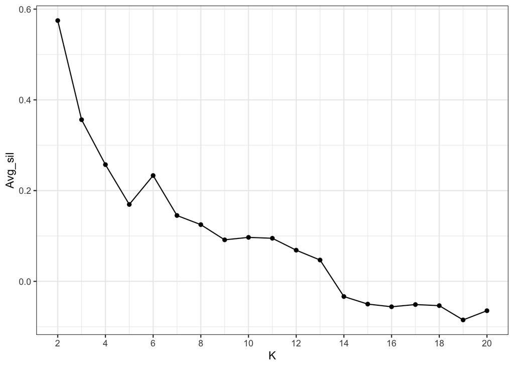

```r
silhouette_summary |>
  ggplot(aes(x = K, y = Avg_sil)) +
  geom_line() +
  geom_point() +
  scale_x_continuous(n.breaks = 10) +
  theme_bw()
```

# Homework Exercise

## K-means on `mtcars`

`mtcars` data is available in R. Load it with `data(mtcars)`.

Use all numeric variables for clustering.

1. Perform elbow (and silhouette) method to determine best `k`.
2. With your choice of `k`, describe the clusters in detail including visualizations.

Report in Quarto `.html`.

# Homework Reading

## Homework Reading

John C. Hull “Machine Learning in Business”

- Chapter 2